# Good practice R coding

Day 1 - Introduction to Data Analysis with R

Selina Baldauf

Freie Universität Berlin - Theoretical Ecology

October 17, 2026

## Chaotic projects and workflows …

… can make even small changes frustrating and difficult.

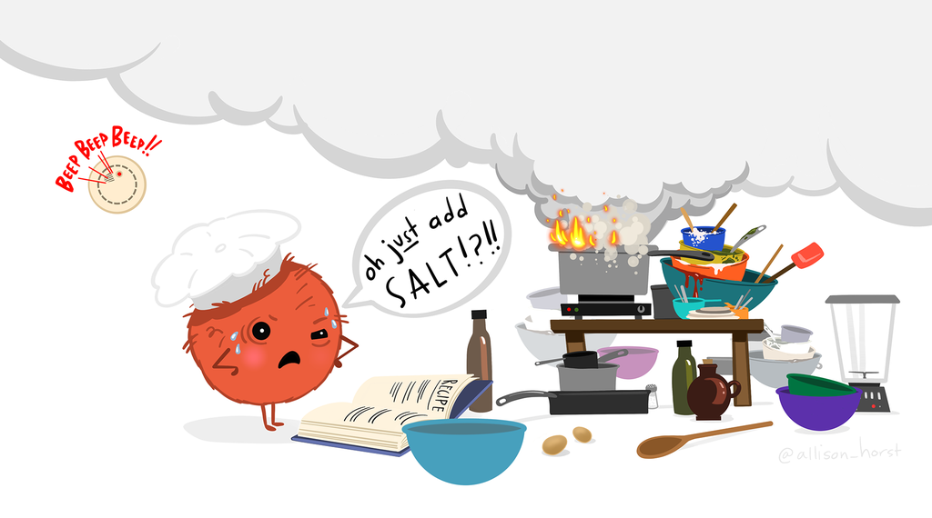

Artwork by [Allison Horst](https://allisonhorst.com), CC BY 4.0

# Set up your project properly

Consistent structure and filenames

## Have a clear project structure

- One directory with all files relevant for project
  - Scripts, data, plots, documents, …
- Choose a meaningful project structure <sup>1</sup>
- Keep your raw data untouched
  - `data/raw` for the original data
  - `data/clean` for cleaned data created by your scripts
- Add a readme file (usually `README.md`) in which you document the project structure

```
MyProject/
├── data/
│   ├── raw/
│   └── clean/
├── R/
├── figures/
├── MyProject.Rproj
└── README.md
```

Example RStudio project structure

[^1]: you can orient yourself at the [R package structure](https://doi.org/10.1080/00031305.2017.1375986)

## Use informative file names

- Human readable: reveal the content
- Machine readable: no spaces, no special characters
- Work with default ordering: left-padded numbers or YYYY-MM-DD dates first

```
MyProject/
├── data/
│   ├── raw/
│   │   └── 2026-10-12_growth-assay.csv
│   └── clean/
│       └── growth-assay_clean.csv
├── R/
│   ├── 01_clean-data.R
│   ├── 02_fit-models.R
│   └── 03_make-figures.R
└── figures/
    └── linear-model-fit.png
```

More on naming: [Jenny Bryan’s talk](https://speakerdeck.com/jennybc/how-to-name-files) on how to name files

# Let’s start coding

> Good practice R coding

## Write beautiful code

- Try to write code that others (i.e. future you) can understand
- Follow standards for readable and maintainable code
  - For R: [tidyverse style guide](https://style.tidyverse.org/index.html) defines code organization, syntax standards, …

[figure not shown]

Artwork by [Allison Horst](https://allisonhorst.com), CC BY 4.0

## Standard code structure

1. General comment with purpose of the script, author, …
2. `library()` calls on top
3. Set default variables and global options
4. Write the actual code, starting with loading all data files

```r
# Analysis of tree growth data
# Author: Selina Baldauf
# Date: 2026-03-09

library(tidyverse)

# set defaults
input_file <- "data/tree_growth.csv"

# read input
trees <- read_csv(input_file)

# analyse data
summary(trees)
```

## Mark sections

- Use comments to break up your file into sections

```r
# Load data ---------------------------------------------------------------

trees <- read_csv("data/tree_growth.csv")

# Explore data -------------------------------------------------------------

summary(trees)
```

- Insert a section label with `Ctrl/Cmd + Shift + R`
- Navigate sections in the file outline

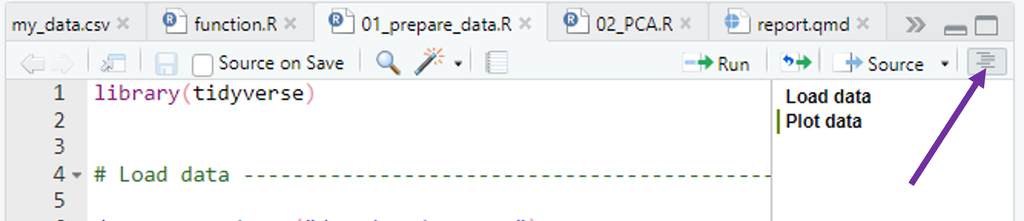

## Coding style - Object names

- Variables should only have *lowercase letters*, *numbers*, and *_*
- Use `snake_case` for longer variable names
- Try to use concise but meaningful names

```r
# Good
day_one
day_1

# Bad
DayOne
dayone
first_day_of_the_month
dm1
```

## Coding style - Spacing

Use spaces to make your code more readable:

- Always put spaces after a comma
- Spaces around most operators (`<-`, `+`, etc.)
- No spaces around parentheses for normal function calls

```r
# Good
x[, 1]
height <- (feet * 12) + inches
mean(x, na.rm = TRUE)

# Bad
x[,1]
height<-feet*12+inches
mean(x,na.rm=TRUE)
```

## Coding style - Line width

Try to limit your line width to 80 characters.

## Coding style

Do I really have to remember all of this?

Luckily, no! R and R Studio provide some nice helpers

## Coding style helpers - RStudio

RStudio has style diagnostics that tell you where something is wrong

**Tools -> Global Options -> Code -> Diagnostics**

[figure not shown]

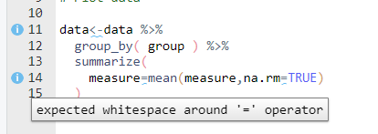

## Coding style helpers - Auto-formatting

RStudio can automatically format your code!

[figure not shown]

Try it now: open your script from today and use **Code -> Reformat Code** to auto-format it.

## Clean projects and workflows …

… allow you and others to work productively.

But don’t get overwhelmed by all the advice. Just start with one thing.

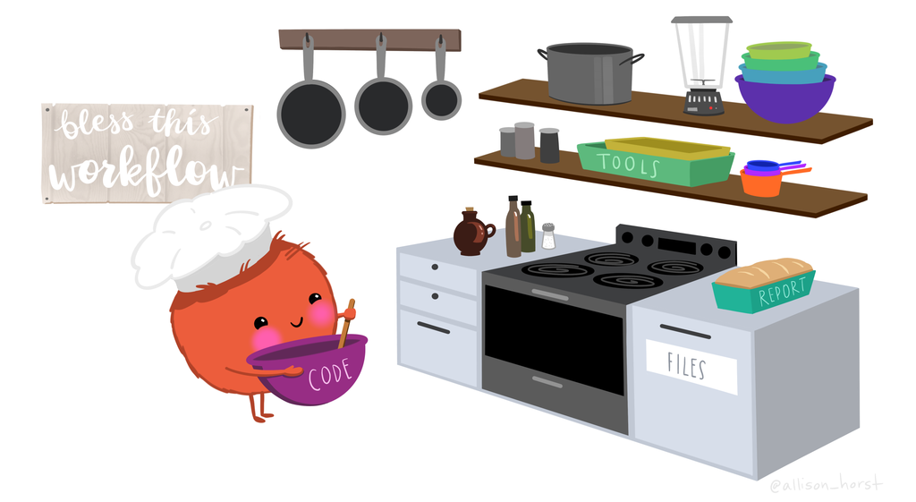

Artwork by [Allison Horst](https://allisonhorst.com), CC BY 4.0